# IODS course project

Yu Ren

# Introduction to Open Data Science - Course Project

# About the project

I just solved the problem of uploading Rstudio to Github before writing chapter 1, thanks to the help of my classmate, I’m very happy to have solved this trouble!

I’m really looking forward to this course, after having studied QSR I’m really looking forward to continuing my in-depth study of R and analytics, and I also really like Kimmo’s course, so I’ve chosen this course.

The R for Health Data Science book was something I had already come across in the QSR and the second time through I was able to get to grips with some of the necessary commands in R. The parts that were difficult to understand before were now understandable and this was a very necessary process. The link: https://github.com/YuRenn/IODS-project

*Describe the work you have done this week and summarize your learning.* Data wrangling and analysis

- Describe your work and results clearly.
- Assume the reader has an introductory course level understanding of writing and reading R code as well as statistical methods.
- Assume the reader has no previous knowledge of your data or the more advanced methods you are using.

1.read date set

```r
learning2014 <- read.table("https://raw.githubusercontent.com/KimmoVehkalahti/Helsinki-Open-Data-Science/master/datasets/learning2014.txt",
                            sep = ",", header = T)
```

2. Show a graphical overview of the data and show summaries of the variables in the data.

```r
View(learning2014)
dim(learning2014)
```

```
## [1] 166   7
```

```r
str(learning2014)
```

```
## 'data.frame':    166 obs. of  7 variables:
##  $ gender  : chr  "F" "M" "F" "M" ...
##  $ age     : int  53 55 49 53 49 38 50 37 37 42 ...
##  $ attitude: num  3.7 3.1 2.5 3.5 3.7 3.8 3.5 2.9 3.8 2.1 ...
##  $ deep    : num  3.58 2.92 3.5 3.5 3.67 ...
##  $ stra    : num  3.38 2.75 3.62 3.12 3.62 ...
##  $ surf    : num  2.58 3.17 2.25 2.25 2.83 ...
##  $ points  : int  25 12 24 10 22 21 21 31 24 26 ...
```

This data set is from international survey of Approaches to Learning, made possible by Teachers’ Academy funding for KV in 2013-2015. Before data wrangling, the data set has 183 observations and 60 variables. Then I did a data wrangling, and choose the variable of attitude, which is a sum of 10 questions related to students attitude towards statistics. In the dataset of learning2014, it has 166 observations and 7 variables, they are gender, age,attitude(Global attitude toward statistics), deep(deep learning), stra(strategical learning), surf(surface learning), and points(exam points).

3.Choose three variables as explanatory variables and fit a regression model where exam points is the target (dependent, outcome) variable. 3.1First, visualize the data set and create a plot matrix with ggpairs()

```r
library(GGally)
```

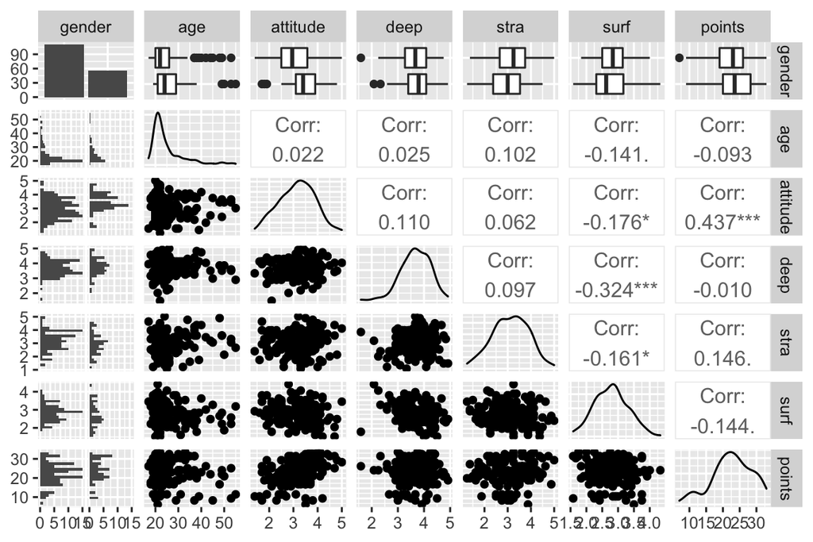

```r
library(ggplot2)
ggpairs(learning2014, lower = list(combo = wrap("facethist", bins = 20)))
```

3.2Choose attitude, points and surf as variables and fit a regression model

```r
fit <- learning2014 %>%
  lm(points ~ attitude + surf, data = .)
summary(fit)
```

```
##
## Call:
## lm(formula = points ~ attitude + surf, data = .)
##
## Residuals:
##     Min      1Q  Median      3Q     Max
## -17.277  -3.236   0.386   3.977  10.642
##
## Coefficients:
##             Estimate Std. Error t value Pr(>|t|)
## (Intercept)  14.1196     3.1271   4.515 1.21e-05 ***
## attitude      3.4264     0.5764   5.944 1.63e-08 ***
## surf         -0.7790     0.7956  -0.979    0.329
## ---
## Signif. codes:  0 '***' 0.001 '**' 0.01 '*' 0.05 '.' 0.1 ' ' 1
##
## Residual standard error: 5.32 on 163 degrees of freedom
## Multiple R-squared:  0.1953, Adjusted R-squared:  0.1854
## F-statistic: 19.78 on 2 and 163 DF,  p-value: 2.041e-08
```

The result shows that expect surf, the p-values for the other variables are both significant and predictive. adjust R-squared shows that the model explains 18.54%.

3.3 remove the variable of surf, and fit the model again.

```r
fit2 <- learning2014 %>%
  lm(points ~ attitude, data = .)
summary(fit2)
```

```
##
## Call:
## lm(formula = points ~ attitude, data = .)
##
## Residuals:
##      Min       1Q   Median       3Q      Max
## -16.9763  -3.2119   0.4339   4.1534  10.6645
##
## Coefficients:
##             Estimate Std. Error t value Pr(>|t|)
## (Intercept)  11.6372     1.8303   6.358 1.95e-09 ***
## attitude      3.5255     0.5674   6.214 4.12e-09 ***
## ---
## Signif. codes:  0 '***' 0.001 '**' 0.01 '*' 0.05 '.' 0.1 ' ' 1
##
## Residual standard error: 5.32 on 164 degrees of freedom
## Multiple R-squared:  0.1906, Adjusted R-squared:  0.1856
## F-statistic: 38.61 on 1 and 164 DF,  p-value: 4.119e-09
```

4.Model diagnostic

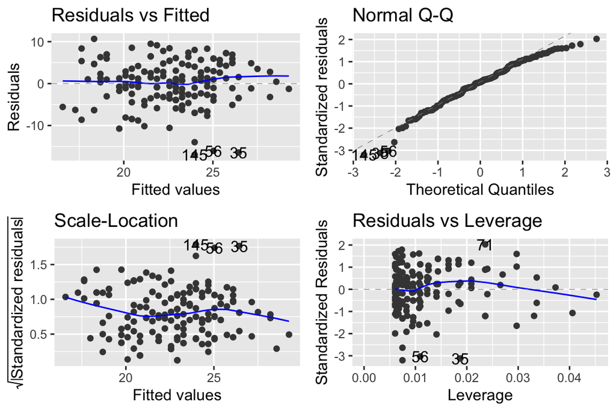

```r
library(ggfortify)
autoplot(fit2)
```

The Residuals vs fitted plot shows the data distributed up and down along the blue line with no clear trend, indicating a linear relationship.

prepare some packages

```r
library(tidyverse)
library(dplyr)
```

1. read the joined student alcohol consumption data

```r
alc <- read_csv("alc.csv")
```

1.2 Print out the names of the variables in the data and describe the data set briefly

```r
glimpse(alc)
```

```
## Rows: 370
## Columns: 35
## $ school     <chr> "GP", "GP", "GP", "GP", "GP", "GP", "GP", "GP", "GP", "GP",…
## $ sex        <chr> "F", "F", "F", "F", "F", "M", "M", "F", "M", "M", "F", "F",…
## $ age        <dbl> 18, 17, 15, 15, 16, 16, 16, 17, 15, 15, 15, 15, 15, 15, 15,…
## $ address    <chr> "U", "U", "U", "U", "U", "U", "U", "U", "U", "U", "U", "U",…
## $ famsize    <chr> "GT3", "GT3", "LE3", "GT3", "GT3", "LE3", "LE3", "GT3", "LE…
## $ Pstatus    <chr> "A", "T", "T", "T", "T", "T", "T", "A", "A", "T", "T", "T",…
## $ Medu       <dbl> 4, 1, 1, 4, 3, 4, 2, 4, 3, 3, 4, 2, 4, 4, 2, 4, 4, 3, 3, 4,…
## $ Fedu       <dbl> 4, 1, 1, 2, 3, 3, 2, 4, 2, 4, 4, 1, 4, 3, 2, 4, 4, 3, 2, 3,…
## $ Mjob       <chr> "at_home", "at_home", "at_home", "health", "other", "servic…
## $ Fjob       <chr> "teacher", "other", "other", "services", "other", "other", …
## $ reason     <chr> "course", "course", "other", "home", "home", "reputation", …
## $ guardian   <chr> "mother", "father", "mother", "mother", "father", "mother",…
## $ traveltime <dbl> 2, 1, 1, 1, 1, 1, 1, 2, 1, 1, 1, 3, 1, 2, 1, 1, 1, 3, 1, 1,…
```

[output cut: 22 more lines]

The dataset has 370 observations and 35 variables. I will explain some meanings of variables: famsize-family size; Pstatus - parent’s cohabitation status; Medu - mother’s education; Fedu - father’s education; Mjob - mother’s job; Fjob - father’s job; reason - reason to choose this school; guardian - student’s guardian; schoolsup - extra educational support; famsup - family educational support; activities - extra-curricular activities; nursery - attended nursery school; higher - wants to take higher education; internet - Internet access at home; romantic - with a romantic relationship; famrel - quality of family relationships; freetime - free time after school; goout - going out with friends; Dalc - workday alcohol consumption; Walc - weekend alcohol consumption; health - current health status; absences - number of school absences; G1 - first period grade; G2 - second period grade; G3 - final grade.

2. Choose 4 variables and present personal hypothesis The four variables I have chosen are goout - going out with friends, freetime - free time after school，famrel - quality of family relationships and absences - number of school absences. I suspect that these four variables would be related to student drinking; having free time after school and going out with friends multiple times may increase the frequency of drinking, the quality of family relationships may also influence drinking status, and there may be a relationship between absence from class and drinking.

3.Explore the distributions of variables and their relationships with alcohol consumption

```r
alc %>% group_by(freetime) %>% summarise(count = n())
```

```
## # A tibble: 5 × 2
##   freetime count
##      <dbl> <int>
## 1        1    17
## 2        2    60
## 3        3   152
## 4        4   105
## 5        5    36
```

```r
alc %>% group_by(goout) %>% summarise(count = n())
```

```
## # A tibble: 5 × 2
##   goout count
##   <dbl> <int>
## 1     1    22
## 2     2    97
## 3     3   120
## 4     4    78
## 5     5    53
```

```r
alc %>% group_by(famrel) %>% summarise(count = n())
```

```
## # A tibble: 5 × 2
##   famrel count
##    <dbl> <int>
## 1      1     8
## 2      2    18
## 3      3    64
## 4      4   180
## 5      5   100
```

```r
alc %>% group_by(absences) %>% summarise(count = n())
```

```
## # A tibble: 26 × 2
##    absences count
##       <dbl> <int>
##  1        0    63
##  2        1    50
##  3        2    56
##  4        3    38
##  5        4    35
##  6        5    22
##  7        6    21
##  8        7    12
##  9        8    20
## 10        9    11
## # … with 16 more rows
```

The distribution of the freetime and goout variables is more in the middle, with the family relationship variables mostly distributed between 3 and 5, indicating that the majority of students have good family relationships; classroom absences, the majority of students are absent 5 times or less.

3.1 explore alcohol high use and freetime

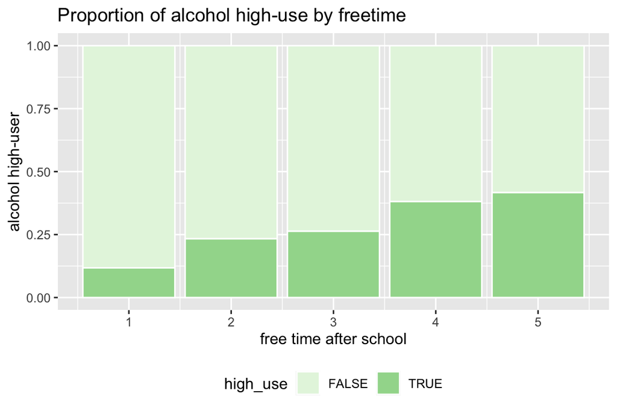

```r
p1 <- alc %>%
  ggplot(aes(x = freetime, fill = high_use)) +
  geom_bar(position = "fill", color ="white") +
  labs(x = "free time after school", y = "alcohol high-user",
       title = "Proportion of alcohol high-use by freetime")+
  theme(legend.position = "bottom")+
  scale_fill_discrete(labels = c("FALSE" = "Non-high-user",
                                 "TRUE" = "high-user"))+
  scale_fill_brewer(palette = "")
p1
```

According to the proportions shown in the bar chart, the proportion of alcohol use increases gradually as leisure time after school increases.

3.2 explore alcohol high use and goout

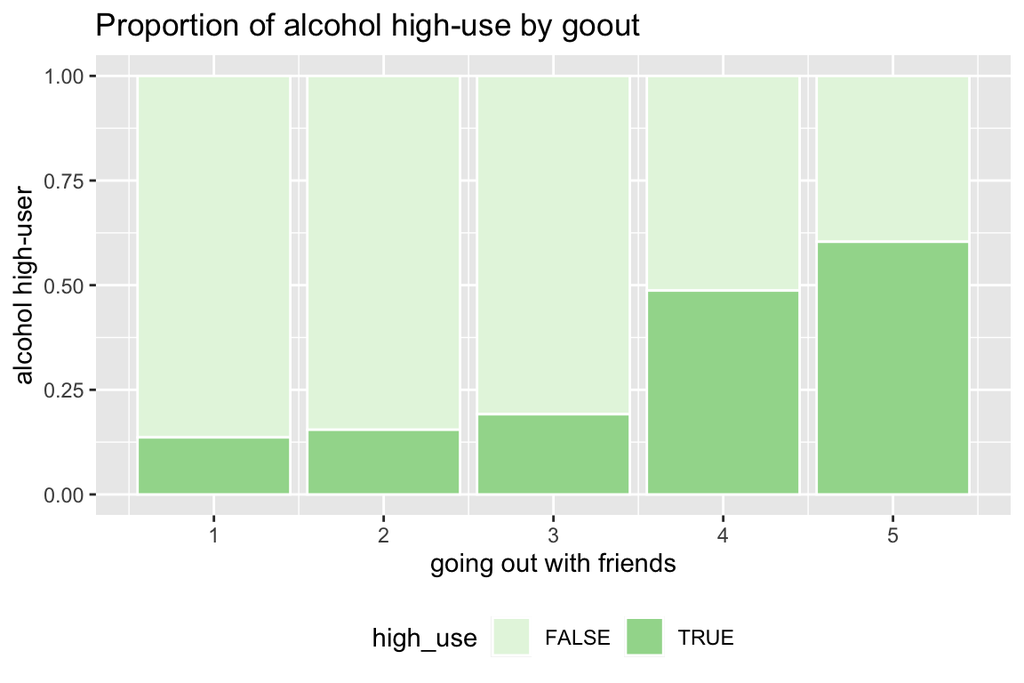

```r
p2 <- alc %>%
  ggplot(aes(x = goout, fill = high_use)) +
  geom_bar(position = "fill", color ="white") +
  labs(x = "going out with friends", y = "alcohol high-user",
       title = "Proportion of alcohol high-use by goout")+
  theme(legend.position = "bottom")+
  scale_fill_discrete(labels = c("FALSE" = "Non-high-user",
                                 "TRUE" = "high-user"))+
  scale_fill_brewer(palette = "")
p2
```

According to the bar scale, the proportion of alcohol consumption increases as the number of outings with friends increases, particularly at level 4 of the outing degree, where the proportion increases substantially.

3.3explore alcohol high use and famrel

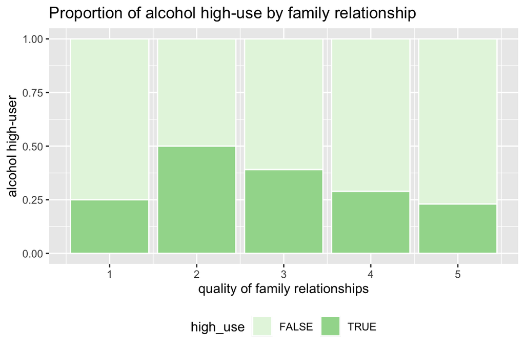

```r
p3 <- alc %>%
  ggplot(aes(x = famrel, fill = high_use)) +
  geom_bar(position = "fill", color ="white") +
  labs(x = "quality of family relationships", y = "alcohol high-user",
       title = "Proportion of alcohol high-use by family relationship")+
  theme(legend.position = "bottom")+
  scale_fill_discrete(labels = c("FALSE" = "Non-high-user",
                                 "TRUE" = "high-user"))+
  scale_fill_brewer(palette = "")
p3
```

“famrel - quality of family relationships (numeric: from 1 - very bad to 5 - excellent)” Family relationships start at level 3, with better family relationships being accompanied by a lower proportion of alcohol consumption. The highest proportion of alcohol consumption is found when family relationships are poor.

3.4 explore alcohol high use and absences

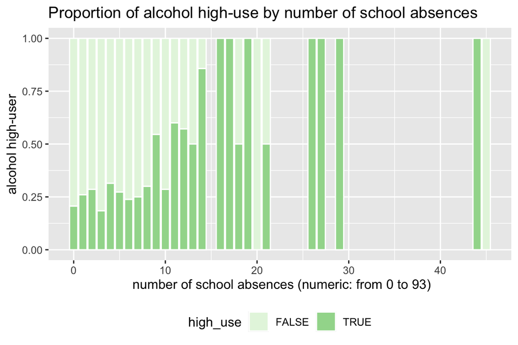

```r
p4 <- alc %>%
  ggplot(aes(x = absences, fill = high_use)) +
  geom_bar(position = "fill", color ="white") +
  labs(x = " number of school absences (numeric: from 0 to 93)", y = "alcohol high-user",
       title = "Proportion of alcohol high-use by number of school absences")+
  theme(legend.position = "bottom")+
  scale_fill_discrete(labels = c("FALSE" = "Non-high-user",
                                 "TRUE" = "high-user"))+
  scale_fill_brewer(palette = "")
p4
```

As the number of absences from school increases, the proportion of alcohol consumption increases with it. The bars show much the same results as I expected, the only differences being family relationships and alcohol consumption rates, with the worst families not having the highest rates of alcohol consumption and the second worst families having the highest rates of alcohol consumption.

4.logistic regression model 4.1

```r
m1 <- glm(high_use ~ freetime + goout + famrel + absences, data = alc, family = "binomial")

summary(m1)
```

```
##
## Call:
## glm(formula = high_use ~ freetime + goout + famrel + absences,
##     family = "binomial", data = alc)
##
## Deviance Residuals:
##     Min       1Q   Median       3Q      Max
## -1.8393  -0.7676  -0.5200   0.9080   2.3909
##
## Coefficients:
##             Estimate Std. Error z value Pr(>|z|)
## (Intercept)  -2.7391     0.6975  -3.927  8.6e-05 ***
## freetime      0.2283     0.1393   1.639 0.101292
## goout         0.7103     0.1252   5.673  1.4e-08 ***
## famrel       -0.4019     0.1387  -2.898 0.003754 **
## absences      0.0761     0.0220   3.459 0.000543 ***
## ---
## Signif. codes:  0 '***' 0.001 '**' 0.01 '*' 0.05 '.' 0.1 ' ' 1
##
## (Dispersion parameter for binomial family taken to be 1)
##
##     Null deviance: 452.04  on 369  degrees of freedom
## Residual deviance: 380.08  on 365  degrees of freedom
## AIC: 390.08
##
## Number of Fisher Scoring iterations: 4
```

There is a highly significant relationship between the proportion of increased drinking and family relationships, the frequency of going out with friends and absence from class, but a non-significant p-value between this and free time.

4.2 From coefficients to odds ratios

```r
m1 <- glm(high_use ~ freetime + goout + famrel + absences, data = alc, family = "binomial")

# compute odds ratios (OR)
OR <- coef(m1) %>% exp
OR
```

```
## (Intercept)    freetime       goout      famrel    absences
##  0.06462506  1.25649062  2.03450512  0.66907685  1.07907060
```

```r
# compute confidence intervals (CI)
confint(m1)
```

```
##                   2.5 %     97.5 %
## (Intercept) -4.14545349 -1.4024140
## freetime    -0.04305995  0.5046433
## goout        0.47111595  0.9630772
## famrel      -0.67730666 -0.1316918
## absences     0.03387575  0.1213892
```

```r
CI <- exp(confint(m1))
CI
```

```
##                  2.5 %    97.5 %
## (Intercept) 0.01583625 0.2460024
## freetime    0.95785396 1.6563946
## goout       1.60178070 2.6197457
## famrel      0.50798332 0.8766111
## absences    1.03445607 1.1290642
```

```r
# print out the odds ratios with their confidence intervals
cbind(OR, CI)
```

```
##                     OR      2.5 %    97.5 %
## (Intercept) 0.06462506 0.01583625 0.2460024
## freetime    1.25649062 0.95785396 1.6563946
## goout       2.03450512 1.60178070 2.6197457
## famrel      0.66907685 0.50798332 0.8766111
## absences    1.07907060 1.03445607 1.1290642
```

5. Explore the predictive power of the model 5.1 Binary predictions（1）

```r
prob <- predict(m1, type = "response")
library(dplyr)

alc <- mutate(alc, probability = prob)
alc <- mutate(alc, prediction = probability > 0.5)

table(high_use = alc$high_use, prediction = alc$prediction)
```

```
##         prediction
## high_use FALSE TRUE
##    FALSE   239   20
##    TRUE     67   44
```

Of the 370 participants, there are 259 non-alcoholics, of which the model correctly predicted 239 (92.28%); of the 111 alcoholics, the model successfully predicted 44 (39.64%).